# Predictive Machine Learning

AIS1209

December 27, 2015

# Summary

Using devices such as Jawbone Up, Nike FuelBand, and Fitbit it is now possible to collect a large amount of data about personal activity relatively inexpensively. In this project, the goal will be to use data from accelerometers on the belt, forearm, arm, and dumbell of 6 participants. The subjects were asked to perform barbell lifts correctly and incorrectly in 5 different ways. A model will be developed to predict the manner in which the subjects performed the exercise, i.e, it will predict the activity type from the data. The outcome variable is the *classe* variable in the training set.

# Building the Model

The train (https://d396qusza40orc.cloudfront.net/predmachlearn/pml-training.csv) and

test (https://d396qusza40orc.cloudfront.net/predmachlearn/pml-testing.csv)

data sets consist of 159 predictor variables. The train data set also contains the outcome variable *classe*. The train and test sets were cleaned up by (1) removing columns containing **NA** and division by zero errors **#DIV/0!**, and (2) removing the first seven columns of categorical data. The remaining predictor set contained 52 predictor variables. Given the non-trivially-sized data set, Random Forests was the algorithm of choice for model building. Some of the features of Random Forests that led to selecting the algorithm as a method for the project are described [here](http://www.stat.berkeley.edu/~breiman/RandomForests/cc_home.htm#overview):

- excellent accuracy;
- efficient on large data bases;
- ability to handle thousands of input variables without variable deletion;
- ability to produce estimates of what variables are important in the classification;
- ability to generate an internal unbiased estimate of the generalization error as the forest building progresses;
- effective method for estimating missing data and maintains accuracy when a large proportion of the data are missing.

# Cross validation and Out-of-sample Accuracy

As described in [1](http://www.stat.berkeley.edu/~breiman/RandomForests/cc_home.htm#overview) “there is no need for cross-validation or a separate test set to get an unbiased estimate of the test set error”. The out-of-bag error (oob) is estimated internally, during the run. For the default settings, the oob estimate of error rate was 0.29% and for 200 trees with 10 trees per node, the same measure was less than 0.50%, as shown below.

```
##
## Call:
##  randomForest(x = train1[, 1:(ncol(train1) - 1)], y = train1$classe,      ntree = 200, nodesize = 10)
##                Type of random forest: classification
##                      Number of trees: 200
## No. of variables tried at each split: 7
##
##         OOB estimate of  error rate: 0.46%
## Confusion matrix:
##      A    B    C    D    E  class.error
## A 5575    5    0    0    0 0.0008960573
## B   18 3776    3    0    0 0.0055306821
## C    0   16 3401    5    0 0.0061367621
## D    0    0   30 3183    3 0.0102611940
## E    0    0    2    9 3596 0.0030496257
```

```
## [1] "Area under ROC curve, 200 trees  1"
```

```
## [1] "Area under ROC curve, 500 trees  0.9"
```

Finally, since overfitting usually is a disadvantage with random trees, `rfcv` was used to analyze the prediction performance of the random forest model (n = 200 trees) depending on the number or predictors. In this case, there does not seem any difference for different number of variables.

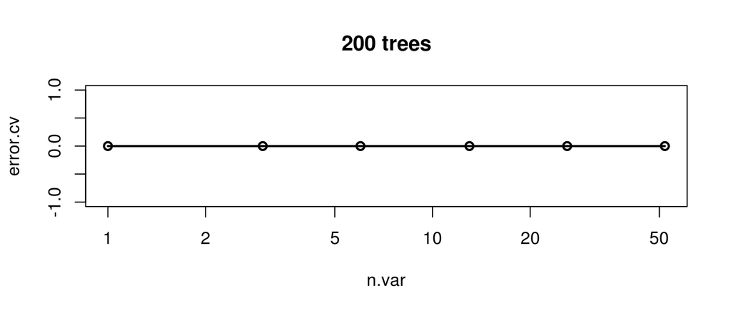

```
##    n.var error.cv
## 52    52        0
## 26    26        0
## 13    13        0
## 6      6        0
## 3      3        0
## 1      1        0
```

# Variable Importance

```
##                  var   overall
## 1          roll_belt 1246.1586
## 3           yaw_belt  901.8520
## 41     pitch_forearm  782.1116
## 39 magnet_dumbbell_z  779.0109
## 2         pitch_belt  700.6379
## 38 magnet_dumbbell_y  674.3402
```

# Prediction on 20 Test Cases

Random Forest models with ntree = 200, nodesize = 10 and default settings (ntree = 500) produced the same classification results on the test data set.

```
##  1  2  3  4  5  6  7  8  9 10 11 12 13 14 15 16 17 18 19 20
##  B  A  B  A  A  E  D  B  A  A  B  C  B  A  E  E  A  B  B  B
## Levels: A B C D E
```

# Appendix – Code

```r
library(car)
library(caret)
library(e1071)
library(randomForest)
library(pROC)

file <- download.file("https://d396qusza40orc.cloudfront.net/predmachlearn/pml-training.csv",
                      destfile = "pml-training.csv")
file1 <- download.file("https://d396qusza40orc.cloudfront.net/predmachlearn/pml-testing.csv",
                      destfile = "pml-testing.csv")
setwd("~/MyStuff/Programming/Rwork/PracticalMachineLearning/Project")
train <- read.csv("pml-training.csv", na.strings = c("NA", "#DIV/0!"))
test <- read.csv("pml-testing.csv")

# Remove columns with NA's
train1 <- train[ , apply(train, 2, function(x) !any(is.na(x)))]
test1 <- test[ , apply(test, 2, function(x) !any(is.na(x)))]
str(train1)
# Eliminate categorical variables.
train1 <- train1[,8:ncol(train1)]
test1 <- test1[,8:(ncol(test1)-1)]

library(randomForest)
modelFit <- randomForest(train1[,1:(ncol(train1)-1)], train1$classe, ntree = 200, nodesize = 10)

# Default produces same answers
modelFit1 <- randomForest(train1[,1:(ncol(train1)-1)], train1$classe)
p <- predict(modelFit, newdata = test1)
p1 <- predict(modelFit1, newdata = test1)

answers <- as.character(p)

pml_write_files = function(x){
    n = length(x)
    for(i in 1:n){
        filename = paste0("problem_id_",i,".txt")
        write.table(x[i],file=filename,quote=FALSE,row.names=FALSE,col.names=FALSE)
    }
}
pml_write_files(answers)

# Variable Importance
vi <- varImp(modelFit1)
vi <- data.frame(var = row.names(vi), overall = vi$Overall)
vi <- vi[order(-vi$overall),]
head(vi)

# Cross validation (overfitting) K-fold
k <- 5
n <- floor(nrow(train1)/k)
err.vec <- vector(mode = "numeric", length = k)
err1.vec <- err.vec
for (ii in 1:k) {
    s1 <- (ii-1)*n +1
    s2 <- ii * n
    subset <- s1:s2
    cv.train <- train1[-subset,]
    cv.test <- train1[subset,]
    fitM <- randomForest(x = cv.train[,-(ncol(cv.train)-1)], y = cv.train[,ncol(cv.train)], ntree = 200, nodesize = 10)
    fitM1 <- randomForest(x = cv.train[,-(ncol(cv.train)-1)], y = cv.train[,ncol(cv.train)])
    prediction <- predict(fitM, newdata = cv.test, type = "prob")[,2]
    prediction1 <- predict(fitM1, newdata = cv.test, type = "prob")[,2]

    err.vec[ii] <- (auc(cv.test[,ncol(cv.test[,-(ncol(cv.train)-1)])], prediction))
    err1.vec[ii] <- (auc(cv.test[,ncol(cv.test[,-(ncol(cv.train)-1)])], prediction1))
}
print(paste("Area under ROC curve ", round(mean(err.vec),2)))
print(paste("Area under ROC curve ", round(mean(err1.vec),2)))

result <- rfcv(train1[,-(ncol(train1)-1)], train1$classe, cv.fold = 5, ntree = 200, nodesize = 10)
with(result, plot(n.var, error.cv, log="x", type="o", lwd=2))
```